# Predictive Analytics & Forecasting - Homework #3

### ARIMA

```r
# Create model
interest_rate_arima = interest_rate_train %>%
  model(ARIMA(interest ~ CPI_lag))

# Print report
report(interest_rate_arima)
```

```
## Series: interest
## Model: LM w/ ARIMA(2,1,0)(0,0,1)[12] errors
##
## Coefficients:
##          ar1      ar2     sma1  CPI_lag
##       0.4754  -0.1577  -0.1369  -0.0504
## s.e.  0.0400   0.0407   0.0410   0.0486
##
## sigma^2 estimated as 0.2392:  log likelihood=-426.81
## AIC=863.63   AICc=863.73   BIC=885.69
```

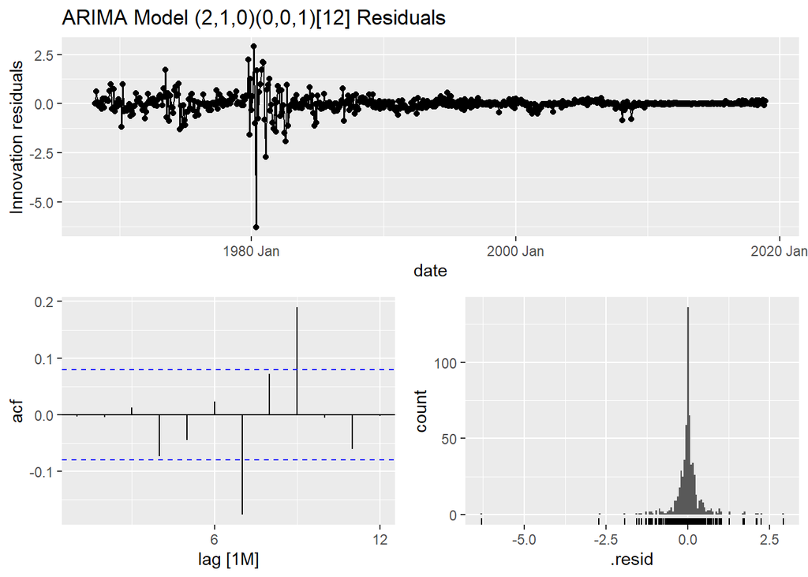

```r
# Plot residuals
interest_rate_arima %>%
  gg_tsresiduals(lag_max = 12) +
  labs(title = "ARIMA Model (2,1,0)(0,0,1)[12] Residuals")
```

```r
# Ljung-Box test
augment(interest_rate_arima) %>%
  features(.innov, ljung_box, lag = 12)
```

```
## # A tibble: 1 × 3
##   .model                    lb_stat   lb_pvalue
##   <chr>                       <dbl>       <dbl>
## 1 ARIMA(interest ~ CPI_lag)    52.1 0.000000600
```

### Neural Network

```r
# Create model
interest_rate_nn = interest_rate_train %>%
  model(NNETAR(interest ~ CPI_lag))

report(interest_rate_nn)
```

```
## Series: interest
## Model: NNAR(27,1,14)[12]
##
## Average of 20 networks, each of which is
## a 28-14-1 network with 421 weights
## options were - linear output units
##
## sigma^2 estimated as 0.01877
```

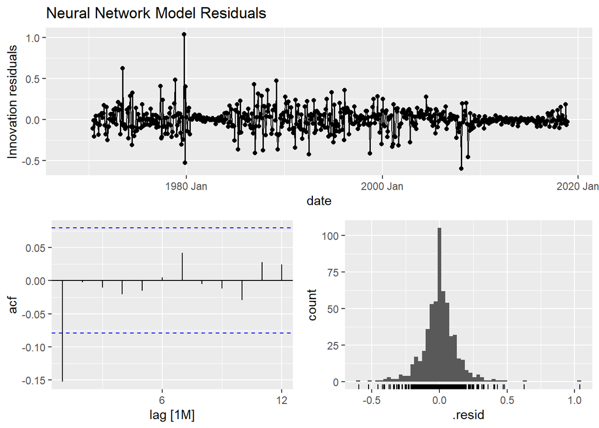

```r
interest_rate_nn %>%
  gg_tsresiduals(lag_max = 12) +
  labs(title = "Neural Network Model Residuals")
```

```r
# Run a Ljung_box test, value is not significant
augment(interest_rate_nn) %>%
  features(.innov, ljung_box, lag = 12)
```

```
## # A tibble: 1 × 3
##   .model                     lb_stat lb_pvalue
##   <chr>                        <dbl>     <dbl>
## 1 NNETAR(interest ~ CPI_lag)    16.6     0.166
```

## Prediction

I will move onto prediction with the three models created along with an ensemble model.

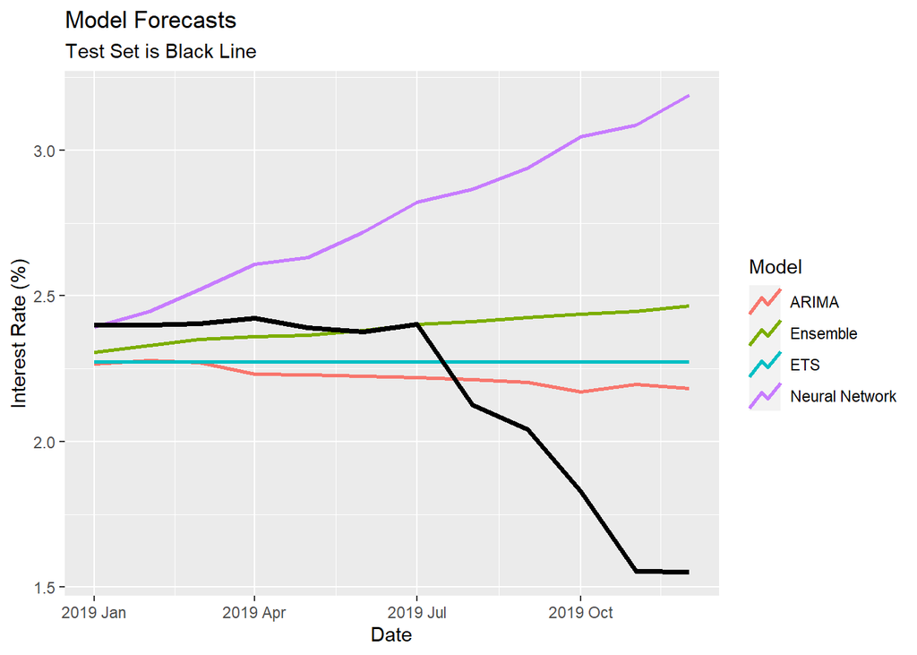

```r
# Build final
interest_rate_model = interest_rate_train %>%
  model(
    `ETS` = ETS(interest),
    `ARIMA` = ARIMA(interest ~ CPI_lag),
    `Neural Network` = NNETAR(interest ~ CPI_lag),
    `Ensemble` = combination_ensemble(ets = ETS(interest),
                                      arima = ARIMA(interest ~ CPI_lag),
                                      nn = NNETAR(interest ~ CPI_lag))
  )

# Forecast
interest_rate_forecast = interest_rate_model %>%
  forecast(interest_rate_test)

# Plot
interest_rate_forecast %>%
  autoplot(level = NULL, lwd = 1) +
  labs(x = "Date", y = "Interest Rate (%)",
       title = "Model Forecasts",
       subtitle = "Test Set is Black Line") +
  guides(color = guide_legend(title = "Model")) +
  geom_line(data = interest_rate_test,
            aes(x = date, y = interest),
            lwd = 1.25)
```

```r
# Calculate accuracy
accuracy_table = interest_rate_forecast %>%
  accuracy(interest_rate_test) %>%
  select(-c(.type, MASE, RMSSE)) %>%
  rename("Model" = ".model")

kable(accuracy_table,
      format = "markdown",
      caption = "Model Accuracy")
```

Model Accuracy

| Model | ME | RMSE | MAE | MPE | MAPE | ACF1 |
| --- | --- | --- | --- | --- | --- | --- |
| ARIMA | -0.0650474 | 0.3072561 | 0.2453737 | -5.633389 | 13.14466 | 0.7374898 |
| ETS | -0.1155900 | 0.3449391 | 0.2624341 | -8.244694 | 14.35984 | 0.7493980 |
| Ensemble | -0.2321545 | 0.4336479 | 0.2828540 | -14.126492 | 16.23457 | 0.7513335 |
| Neural Network | -0.6139276 | 0.8300592 | 0.6151706 | -33.793740 | 33.84553 | 0.7585545 |

As seen above, none of the models particularly forecast well compared to previous models I have done in this course. The ARIMA model performs the best, but the MAPE is still 13.1%. The neural network performs the worst. Future work would include attempting other predictors for the data set along with other models (such as a TSLM). It is also worth noting that interest rates since the Great Recession post 2007 has been historically low as the economy has rebounded.